# Lab 2 Assignment 2 Report

2025-12-02

### Part 1

The data for the lab is imported and prepared as follows:

```r
data <- read.csv2("./bank-full.csv")

# Exclude "duration" input variable
data <- data[ , -which(names(data) == "duration")]

# Convert all character columns to factors to avoid NAs during
#construction of decision trees
data[] <- lapply(data, function(x) if (is.character(x)) factor(x) else x)

# Code taken from slide 20 of lecture 2a
n=dim(data)[1]
set.seed(12345)
id=sample(1:n, floor(n*0.4))
train=data[id,]
id1=setdiff(1:n, id)
set.seed(12345)
id2=sample(id1, floor(n*0.3))
valid=data[id2,]
id3=setdiff(id1,id2)
test=data[id3,]
```

### Part 2 - Construction of three different decision trees

For the second part of the lab we fit three separate decision trees:

#### Decision tree with default settings

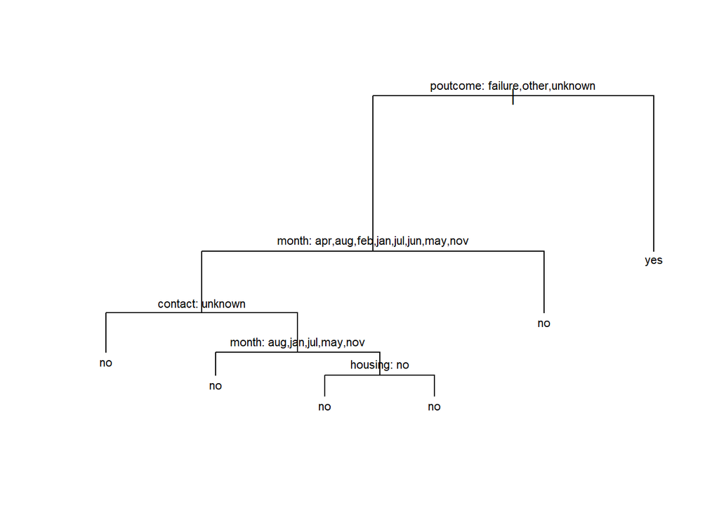

```r
fit1 <- tree(y~., data=train)
plot(fit1)
text(fit1, pretty = 0, cex=0.7)
```

The default settings tree has the following misclassification rates for training and validation data.

```
## [1] "fit1 training misclassification:  0.104844061048441"
```

```
## [1] "fit1 validation misclassification:  0.109267861092679"
```

#### Decision tree with smallest allowed node size equal to 7000

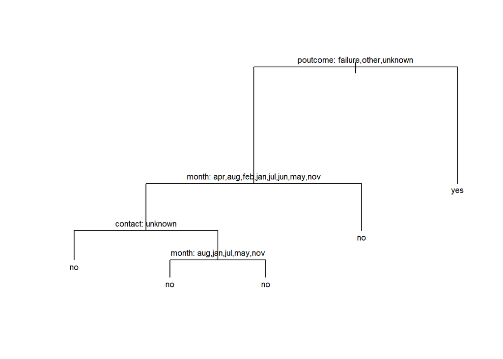

```r
ctrl <- tree.control(nobs <- nrow(train), minsize=7000)
fit2 <- tree(y~., data=train, control=ctrl)
plot(fit2)
text(fit2, pretty = 0, cex=0.7)
```

The minimum node size tree has the following misclassification rates for training and validation data.

```
## [1] "Fit2 training misclassification:  0.104844061048441"
```

```
## [1] "Fit2 validation misclassification:  0.109267861092679"
```

#### Decision tree with minimum deviance 0.0005

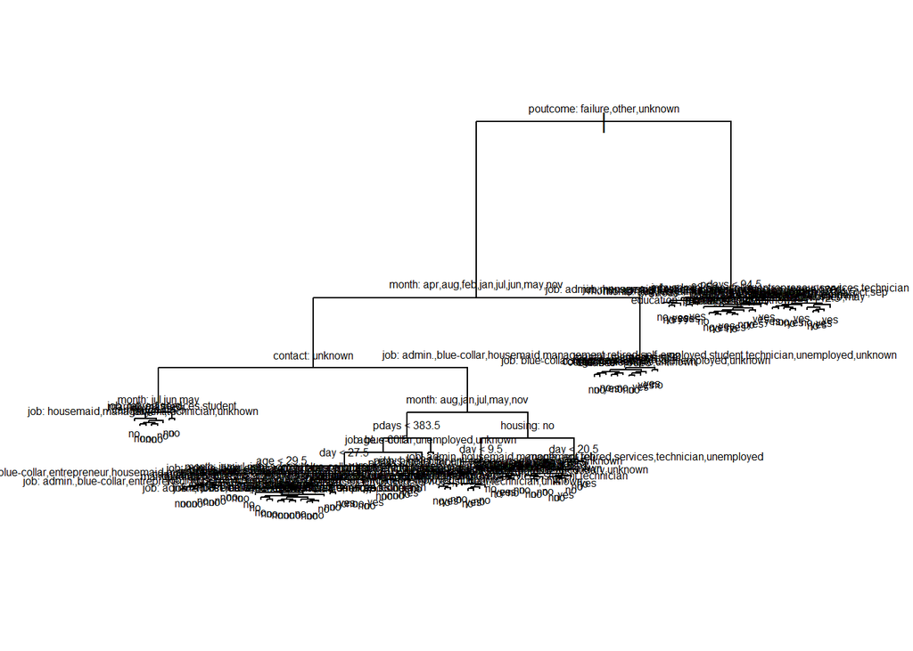

```r
ctrl <- tree.control(nobs <- nrow(train), mindev=0.0005)
fit3 <- tree(y~., data=train, control=ctrl)
plot(fit3)
text(fit3, pretty = 0, cex=0.5)
```

The tree with minimum deviance 0.0005 has the following misclassification rates for training and validation data.

```
## [1] "Fit3 training misclassification:  0.0940057509400575"
```

```
## [1] "Fit3 validation misclassification:  0.111922141119221"
```

### Part 3 - Find optimal tree depth for min deviance 0.0005 tree

To find the optimal tree depth for our fit3 tree we prune the tree to all possible amounts of leaves between 2 and 50. For each tree we record its deviance for the training and validation data. This gives the following plot of the dependence of deviances for the training and validation data on the number of leaves.

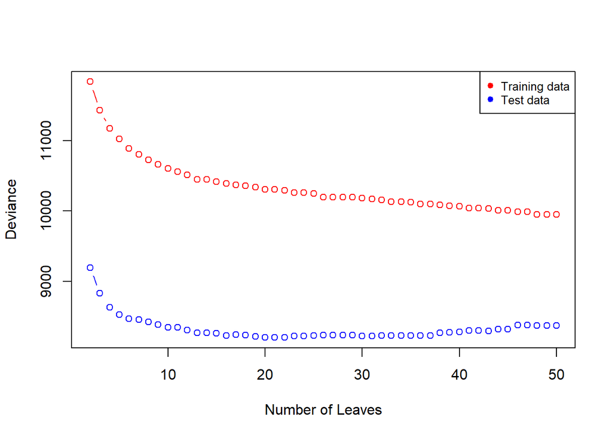

From the plot we see the deviance of the training data is always decreasing with more leaves. The deviance for the test data decreases until around 20 leaves whereafter it gets unstable. This is due to the decision tree overfitting to the training data at higher amounts of leaves. The optimal amount of leaves is gotten as follows:

```r
optimal_leaves <- which.min(test_deviances[2:50]) + 1
print(paste("The optimal number of leaves is:", optimal_leaves))
```

```
## [1] "The optimal number of leaves is: 22"
```

With the optimal amount of leaves we create a optimal tree from fit3 with 22 leaves.

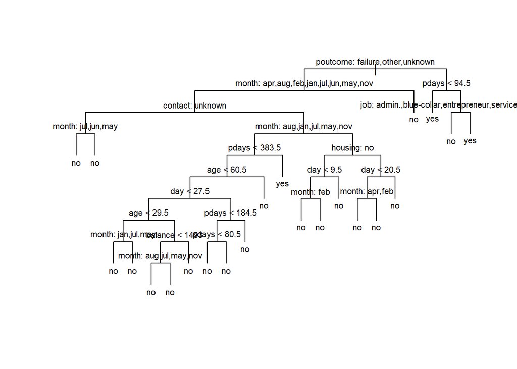

From the decision tree we can see that the most important variable for decision making is the outcome of previous campaigns towards a specific customer (poutcome).

In the left branch the majority of outcomes result in “no”. There is a single leaf resulting in “yes” when the contact is “known” and its been more than 383 days since last contact. This could be interpreted as a new customers that may not have been ever contacted before and is now receiving their first campaign call.

### Part 4 - Statistics of optimal tree

```
##       Predicted
## Actual    no   yes
##    no  11872   107
##    yes  1371   214
```

From the confusion matrix of the optimal tree we calculate the accuracy and F1-score.

```
## [1] "Accuracy for optimal tree:  0.891035092892952"
```

This gives us a total misclassification of only about 10% which might appear good but in our data set the majority of outcomes result in “no” with few “yes”. This means it might be more appropriate to use F1-score as a measure for predictive power to make sure the model is also good at predicted the less common outcomes.

```
## [1] "F1 Score for optimal tree:  0.224554039874082"
```

The F1-score is very low which indicates that the decision tree is not very good at predicting cases of “yes”. For our tree the F1-score should be the preferred as the data set is unbalanced.

### Part 5 - Decision tree classification with loss matrix

When applying the loss matrix given in the lab instructions to the predictions of the optimal tree we get the following confusion matrix:

```
##       Predicted
## Actual    no   yes
##    no  11030   949
##    yes   771   814
```

From this confusion matrix we calculate the accuracy and F1-score again.

```
## [1] "Accuracy for tree with loss matrix:  0.873193748156886"
```

```
## [1] "F1 Score for tree with loss matrix:  0.486260454002389"
```

With the loss matrix the decision tree will try harder to predict “yes” correctly at the cost of slightly lower accuracy. Our data set is unbalanced which makes the F1-score a more important statistic to optimize for.

### Part 6 - Compute TPR and FPR for a logistic regression model and decision tree

In the last part of the lab we compare the classification performance between the optimal tree and a logistic regression model using the following principle. $\hat{Y} = \text{yes if } p(Y=\text{'yes'} \mid X) > \pi,\ \text{otherwise } \hat{Y} = \text{no}$ where $\pi$ = 0.05,0.1,0.15, … 0.9,0.95.

For each value of $\pi$ we calculate the true positive rate (TPR) and false positive rate (FPR) for both models. Lastly all values are inserted into a plot.

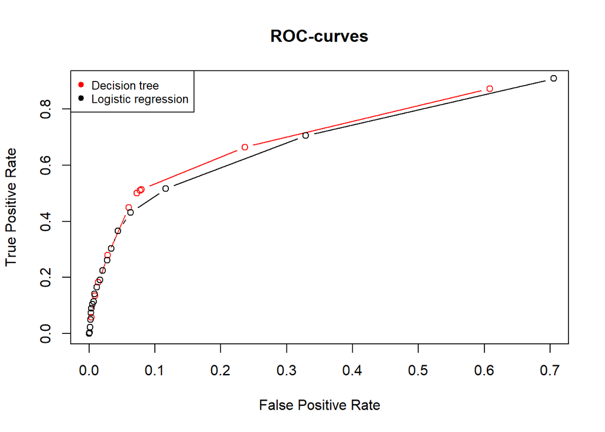

A precision-recall curve is better at showing performance on predictions on the positive outcomes of a model. As previously stated our data set is unbalanced with the majority of outcomes being “no”. This means a PR curve could be more appropriate, just as F1-score is more appropriate than accuracy for our decision trees.

## Assignment 4

#### What important aspect should be considered when selecting minibatches, according to the book?

It is very important to make sure that all different mini-batches are balanced and representative of the whole data set. If we have a big data set with a lot of different possible output classes and use mini-batches that are not balanced some of the mini-batches might not contain all of the output classes and are therefor not a good representation of the full data set. This will give bad approximations of the gradient for the full data set.